# Assigment 3

This assigment focuses on getting comfortable with working with multidimensional data and linear regression. Key items include:

- Creating random n-dimensional data
- Creating a Model that can handle the data
- Plot a subset of the data along with the prediction
- Using a Dataset to read in and choose certain columns to produce a model
- Create several models from various combinations of columns
- Plot a few of the results

## 1. Create a 4 dimensional data set with 64 elements and show all 4 scatter 2D plots of the data $x_1$ vs. $y$, $x_2$ vs. $y$, $x_3$ vs. $y$, $x_4$ vs. $y$

```python
# Import libraries
import numpy as np
import matplotlib.pyplot as plt
%matplotlib inline
```

```python
# The data set will have 64 rows and 4 columns
n = 64
# Generate a 4 dimensional matrix with random data
x = np.linspace(0, 1, n) + np.random.rand(4, n)
# Generate a 1 dimensional vector with random data for our y value
# We are loading it with values that will force a trend
y = np.linspace(0, 1, n) + np.random.rand(n) - 1
```

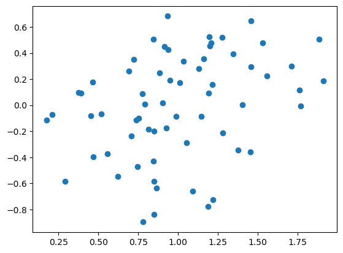

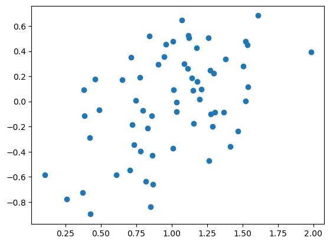

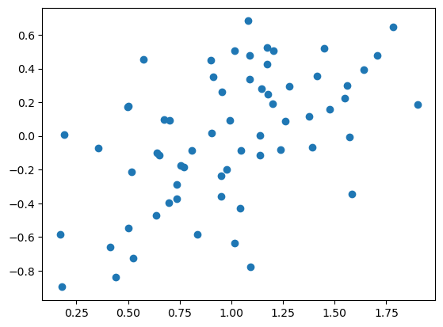

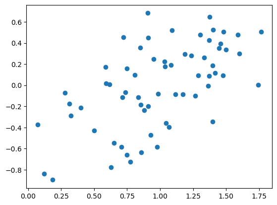

```python
# Plot all 4 x values against the y value as separate scatter plots

plt.scatter(x[0], y)
plt.show()
plt.scatter(x[1], y)
plt.show()
plt.scatter(x[2], y)
plt.show()
plt.scatter(x[3], y)
plt.show()
```

## 2. Create a Linear Regression model (LIKE WE DID IN CLASS) to fit the data. *Use the example from Lesson 3 and DO NOT USE a library that calculates automatically*. We are expecting 5 coefficients to describe the linear model.

## After creating the model (finding the coefficients), calculate a new column $y_p=\Sigma\beta_n\cdot x_n$

```python
# add a column of 1s to our data set to act as a placehodler for the error value
x = np.vstack([x, np.ones(len(x.T))]).T
# This also transposes the data to make it look like a data frame
```

Making use of the following equation: $\beta = (X^T X)^{-1} Y^T X$

```python
# Calculate the left side first
left = np.linalg.inv(np.dot(x.T, x))
# Calculate the right side
right = np.dot(y.T, x)
# Multiply together with dot product
beta = np.dot(left, right)

# Print the results
beta
```

```
array([-0.0655046 ,  0.26822135,  0.23722764,  0.35117683, -0.79327848])
```

```python
# Predict new values using the beta values
yhat = np.dot(x, beta)
yhat
```

```
array([-0.47414291, -0.53182908, -0.35883527, -0.25381493, -0.19414755,
       -0.46047407, -0.62225398, -0.38266049, -0.07307276, -0.17080124,
       -0.08817313, -0.41018249, -0.25423335, -0.32147202, -0.27219967,
       -0.10790331, -0.08989423, -0.37716523,  0.09468636, -0.11035152,
        0.10286826, -0.09901914, -0.049961  , -0.39223538, -0.29686779,
       -0.0260726 ,  0.09576225,  0.08533554, -0.21788794,  0.07522543,
       -0.1072262 , -0.36133184,  0.1543365 ,  0.08195653, -0.22410835,
        0.2213973 ,  0.15502007,  0.07579787,  0.08881235,  0.01744856,
        0.18106548,  0.29391621,  0.33140248,  0.07601508,  0.04827558,
        0.24523425,  0.0565441 ,  0.1988854 ,  0.24212598,  0.394871  ,
        0.15178307,  0.01828068,  0.09180915,  0.26051724,  0.40552522,
        0.32825129,  0.1491682 ,  0.18417436,  0.22008381,  0.32925522,
        0.1450128 ,  0.3038639 ,  0.3178886 ,  0.55166974])
```

## 3. Plot the model's prediction as a different color on top of the scatter plot from Q1 in 2D for all 4 of the dimensions ($x_1 \rightarrow y_p, x_2 \rightarrow y_p, x_3 \rightarrow y_p, x_4 \rightarrow y_p$)

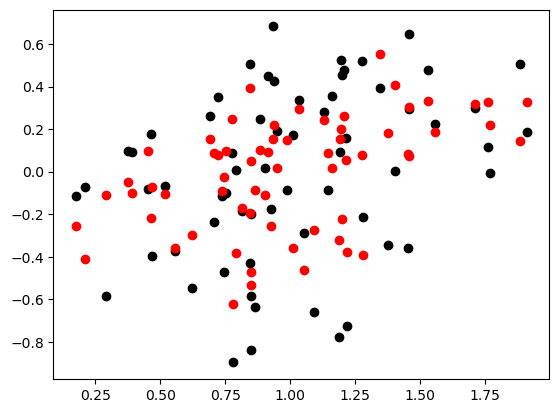

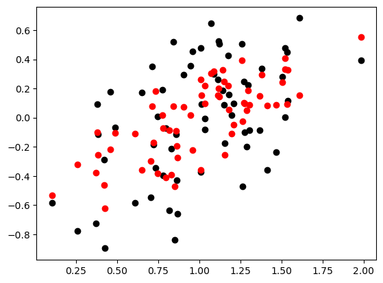

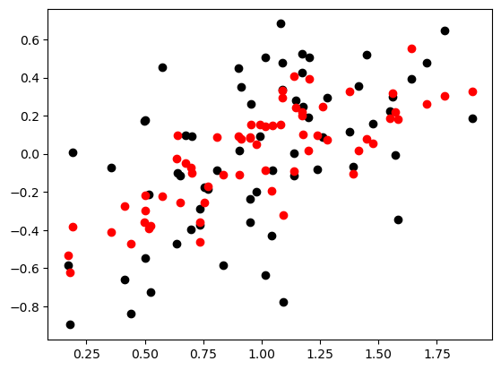

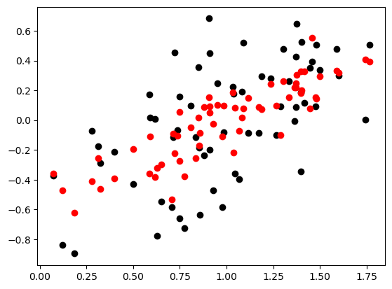

```python
# Plot each set of data in turn against the predicted values
plt.scatter(x.T[0], y, color='black')
plt.scatter(x.T[0], yhat, color='red')
plt.show()

plt.scatter(x.T[1], y, color='black')
plt.scatter(x.T[1], yhat, color='red')
plt.show()

plt.scatter(x.T[2], y, color='black')
plt.scatter(x.T[2], yhat, color='red')
plt.show()

plt.scatter(x.T[3], y, color='black')
plt.scatter(x.T[3], yhat, color='red')
plt.show()
```

## 4. Read in `mlnn/data/Credit.csv` with Pandas and build a Linear Regression model to predict Credit Rating (`Rating`). Use only the numeric columns in your model, but feel free to experiment which which columns you believe are better predicters of Credit Rating (Column `Rating`)

```python
import pandas as pd
import numpy as np
credit = pd.read_csv('../mlnn-main/data/Credit.csv')
credit.head()
```

|  | Unnamed: 0 | Income | Limit | Rating | Cards | Age | Education | Gender | Student | Married | Ethnicity | Balance |
| --- | --- | --- | --- | --- | --- | --- | --- | --- | --- | --- | --- | --- |
| 0 | 1 | 14.891 | 3606 | 283 | 2 | 34 | 11 | Male | No | Yes | Caucasian | 333 |
| 1 | 2 | 106.025 | 6645 | 483 | 3 | 82 | 15 | Female | Yes | Yes | Asian | 903 |
| 2 | 3 | 104.593 | 7075 | 514 | 4 | 71 | 11 | Male | No | No | Asian | 580 |
| 3 | 4 | 148.924 | 9504 | 681 | 3 | 36 | 11 | Female | No | No | Asian | 964 |
| 4 | 5 | 55.882 | 4897 | 357 | 2 | 68 | 16 | Male | No | Yes | Caucasian | 331 |

## Choose multiple columns as inputs beyond `Income` and `Limit` but clearly, don't use `Rating`

```python
columns = ['Income', 'Limit', 'Age', 'Balance']
X = credit[columns].values

X = np.vstack([X.T, np.ones(len(X))]).T
X
```

```
array([[1.48910e+01, 3.60600e+03, 3.40000e+01, 3.33000e+02, 1.00000e+00],
       [1.06025e+02, 6.64500e+03, 8.20000e+01, 9.03000e+02, 1.00000e+00],
       [1.04593e+02, 7.07500e+03, 7.10000e+01, 5.80000e+02, 1.00000e+00],
       ...,
       [5.78720e+01, 4.17100e+03, 6.70000e+01, 1.38000e+02, 1.00000e+00],
       [3.77280e+01, 2.52500e+03, 4.40000e+01, 0.00000e+00, 1.00000e+00],
       [1.87010e+01, 5.52400e+03, 6.40000e+01, 9.66000e+02, 1.00000e+00]])
```

```python
y = credit['Rating']
y
```

```
0      283
1      483
2      514
3      681
4      357
      ...
395    307
396    296
397    321
398    192
399    415
Name: Rating, Length: 400, dtype: int64
```

```python
# add a column of 1s to our data set to act as a placehodler for the error value
#x = np.vstack([x, np.ones(len(x.T))]).T
# This also transposes the data to make it look like a data frame

# Calculate the left side first
left = np.linalg.inv(np.dot(X.T, X))
# Calculate the right side
right = np.dot(y.T, X)
# Multiply together with dot product
beta = np.dot(left, right)

# Print the results
beta
```

```
array([1.31880513e-01, 6.26253800e-02, 3.19381468e-02, 1.50244935e-02,
       4.28168820e+01])
```

```python
# Predict new values using the beta values
pred_score = np.dot(X, beta)
pred_score
```

```
array([276.6968883 , 489.13120906, 510.66703854, 673.28205191,
       364.00801595, 577.08992362, 261.99231627, 513.63113601,
       257.77508011, 500.82343953, 581.56569911, 128.94693888,
       390.74954943, 499.87701353, 256.06071413, 205.41578846,
       284.80755971, 329.53665253, 463.4357167 , 480.47299757,
       227.60903702, 464.01028526, 212.18367766, 383.30573643,
       156.08680948, 326.28448495, 286.66627894, 339.50682946,
       935.97588956, 413.24801096, 416.62218029, 219.16213974,
       560.80638405, 162.45354245, 211.97948346, 213.95224597,
       469.13629151, 471.27481181, 297.32522896, 268.03261418,
       258.25662975, 556.91528222, 354.81749426, 454.96452125,
       463.88141086, 543.60962459, 381.90186944, 339.73736863,
       192.02036849, 349.80333833, 383.59065365, 300.64582903,
       399.53324085, 403.76374689, 140.21554341, 160.92307843,
       355.53420782, 356.23673249, 269.35752182, 391.76154557,
       383.62497474, 242.57455508, 153.96948716, 236.82512527,
       233.51254144, 314.86004213, 687.61304287, 379.17954874,
       413.22267792, 494.43084634, 301.47911376, 533.28101934,
       365.60916688, 339.25496047, 398.12671503, 247.64986768,
       263.2455279 , 252.49761487, 481.97347378, 178.4936783 ,
       266.13274916, 320.98013775, 333.12649048, 136.30810397,
       232.7520459 , 846.57789325, 460.46254054, 188.47187972,
       325.11611051, 540.81492369, 423.35170687, 441.17109988,
       225.85388742, 400.26742346, 241.83978848,  99.68814179,
       404.37230273, 263.12161809, 240.96846517, 607.0133764 ,
       285.36173322, 206.2663426 , 552.33682618, 677.42533195,
       356.39044185, 248.68505173, 131.12853626, 249.98661221,
       440.33164993, 254.47066379, 254.74588278, 233.81015585,
       481.58597813, 464.37237142, 258.66365222, 360.75520987,
       182.01413734, 647.21977595, 182.99377122, 136.74049204,
       136.35007763, 582.65295911, 509.22249353, 128.24635839,
       206.05352788, 206.04461653, 415.49961204, 266.2754288 ,
       605.38613252, 267.57607612, 300.07608858, 143.89718296,
       402.02470655, 428.53970451, 427.81216972, 270.57801984,
       311.15443779, 277.80431137, 177.82153166, 734.11368909,
       449.07216071, 488.04912985, 533.68235259, 364.73177997,
       219.24877835, 349.31534755, 378.93311125, 141.75238698,
       198.57650741, 101.48124875, 419.58981048, 360.22085267,
       184.15538305, 344.81493299, 248.65085192, 131.77509612,
       324.1401296 , 413.615205  , 408.43566427, 239.4174808 ,
```

[output cut: 45 more lines]

```
       290.82286366, 299.03860057, 234.04638407, 286.39261355,
       385.52133925, 142.45578796, 397.83964439, 757.15874094,
       117.84128412, 381.25575037, 146.76744958, 379.6428178 ,
       513.81011046, 351.56624998, 294.56690702, 838.98243963,
       444.35602227, 208.32390289, 326.1320729 , 336.1447812 ,
       432.12367448, 366.60093181, 378.3667588 , 446.22496233,
       695.83284997, 475.32697158, 564.57455495, 277.82642458,
       421.57897268, 574.996954  , 447.90167674, 185.01544812,
       296.36465874, 401.67220787, 361.06270957, 417.28649654,
       516.20195158, 146.29134308, 366.62716127, 231.63855947,
       556.55436737, 574.49851088, 411.58422098, 257.5206103 ,
       165.00285748, 414.95524983, 283.39981348, 131.95954075,
       494.87342618, 512.04320543, 746.60369199, 475.20265032,
       191.54823898, 130.78138679, 422.28618234, 310.61190371,
       294.22327801, 315.8727669 , 207.32683292, 407.78348067])
```

### 5. Plot your results using scatter plots (just like in class). Show as many of your columns vs. credit rating that you can.

```
0
```

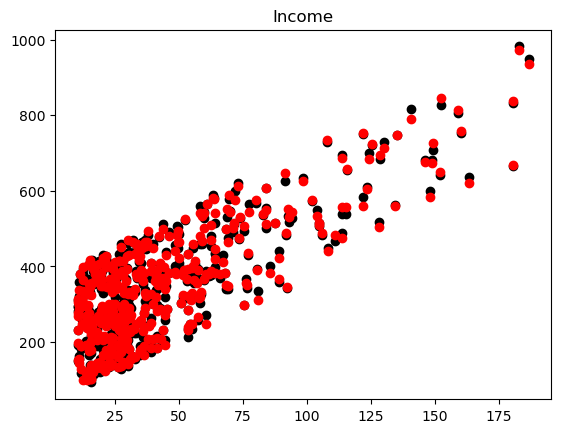

```
1
```

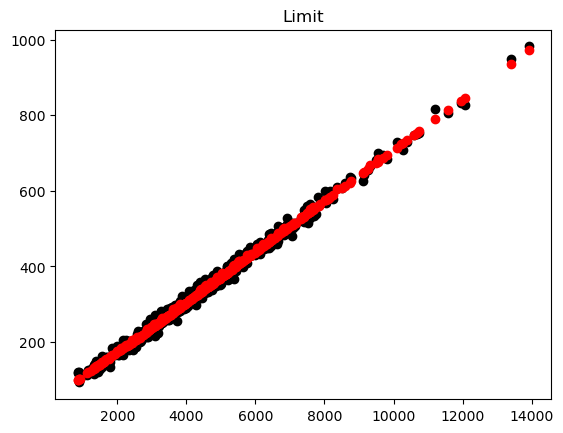

```
2
```

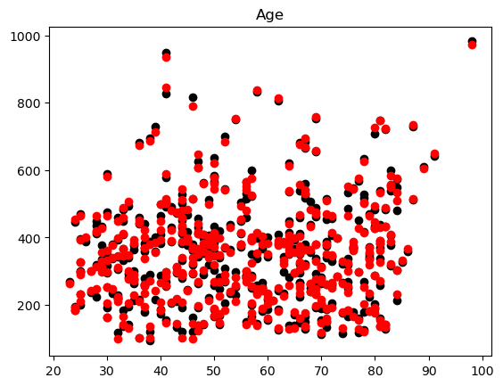

```
3
```

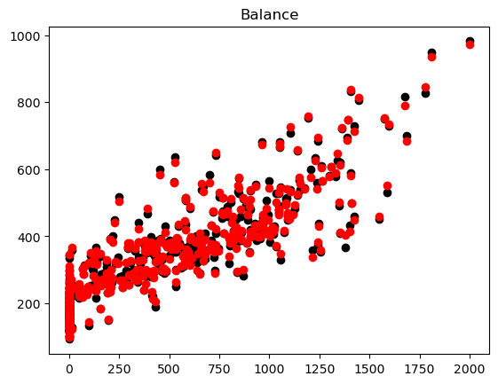

```python
# Plot each set of data in turn against the predicted values
for i in range(len(X.T)-1):
    print(i)
    plt.scatter(X.T[i], y, color='black')
    plt.scatter(X.T[i], pred_score, color='red')
    plt.title(columns[i])
    plt.show()
```